# MScA, Linear and Non-Linear Models (31010) Week 10 Workshop

## 3.2 Data from the Speed-Accuracy Trade-Off in Response Time Experiments

### 3.2.1 Estimating States

Estimate hidden states for the speed-accuracy trade-off data `speed` using SOM.

```r
library(depmixS4)
```

```r
data(speed)
head(speed)
```

```
##         rt corr Pacc prev
## 1 6.456770  cor    0  inc
## 2 5.602119  cor    0  cor
## 3 6.253829  inc    0  cor
## 4 5.451038  inc    0  inc
## 5 5.872118  inc    0  inc
## 6 6.003887  cor    0  inc
```

```r
speed.som<-som(as.matrix(speed[,c(1)]),grid=somgrid(1,2,"hexagonal"))
speed.som$codes
```

```
## [[1]]
##        [,1]
## V1 6.409002
## V2 5.506479
```

Compare the codes of the 2 classes with the states estimated by the 2-state model `fm2` and `fm2a`

```r
getpars(fm2)[c(3,5)]
```

```
## (Intercept) (Intercept)
##    5.475247    6.313604
```

```r
getpars(fm2a)[c(11,15)]
```

```
## (Intercept) (Intercept)
##    5.631697    6.431112
```

Plot the trajectory of improvement of distances and response time with the levels of states,

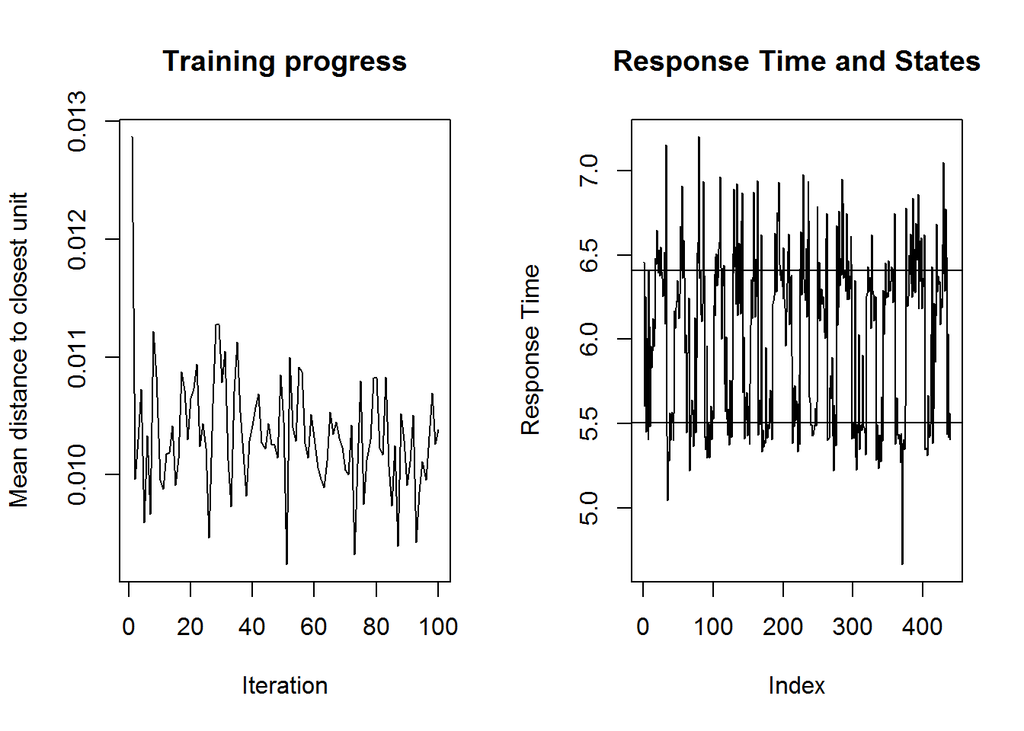

```r
par(mfrow=c(1,2))
plot(speed.som,"changes")
plot(speed[,1],type="l",main="Response Time and States",ylab="Response Time")
abline(h=speed.som$codes[[1]])
```

```r
par(mfrow=c(1,1))
```

Train SOM on the combined columns of response time, binary variable of accuracy Acc and the payoff for accuracy Pacc.

```r
dataSOM<-cbind(speed[,1],ifelse(speed[,2]=="cor",1,0),speed[,3])
head(dataSOM)
```

```
##          [,1] [,2] [,3]
## [1,] 6.456770    1    0
## [2,] 5.602119    1    0
## [3,] 6.253829    0    0
## [4,] 5.451038    0    0
## [5,] 5.872118    0    0
## [6,] 6.003887    1    0
```

```r
speed.rt.Pacc.som<-som(dataSOM,grid=somgrid(1,2,"hexagonal"))
names(speed.rt.Pacc.som)
```

```
##  [1] "data"             "unit.classif"     "distances"
##  [4] "grid"             "codes"            "changes"
##  [7] "alpha"            "radius"           "user.weights"
## [10] "distance.weights" "whatmap"          "maxNA.fraction"
## [13] "dist.fcts"
```

Check how the map improved in the process of training.

```r
speed.rt.Pacc.som$unit.classif
```

```
##   [1] 1 2 2 2 2 1 2 1 2 2 1 2 1 2 1 1 1 1 1 1 1 1 1 1 1 1 1 1 1 1 1 1 1 2 2
##  [36] 2 2 2 2 2 2 2 2 2 1 2 1 1 1 1 1 1 1 1 1 1 1 1 1 2 2 2 1 2 1 2 2 2 2 2
##  [71] 2 2 2 1 2 1 1 1 1 1 1 1 1 1 1 1 1 2 2 2 2 2 2 2 2 2 2 2 2 2 1 1 1 1 1
## [106] 1 1 1 1 1 1 1 1 1 1 2 2 2 2 2 2 2 2 2 2 2 2 1 1 1 1 1 1 1 1 1 1 1 1 1
## [141] 1 1 2 2 2 2 2 2 2 2 2 2 2 1 1 1 1 1 1 2 1 1 1 1 2 2 2 2 1 2 2 2 2 2 2
## [176] 2 2 2 2 2 2 2 2 2 1 1 2 1 1 1 1 1 1 1 1 1 1 1 1 1 1 1 1 1 1 1 1 1 2 1
## [211] 1 1 1 2 2 2 2 2 2 2 2 2 2 2 1 1 1 1 1 1 1 1 1 2 1 1 1 2 2 2 2 2 2 2 2
## [246] 2 2 2 1 1 1 1 1 1 1 1 1 1 1 2 1 1 1 2 2 2 2 2 2 2 2 2 2 2 2 2 1 1 1 1
## [281] 1 1 1 1 1 1 1 1 1 1 1 1 1 1 1 1 1 1 2 2 2 2 1 2 2 2 2 1 2 2 2 2 2 1 2
## [316] 2 2 2 2 1 1 1 1 1 1 1 1 1 1 1 1 2 2 2 2 2 2 2 2 2 2 2 1 1 1 1 1 1 1 1
## [351] 1 1 1 1 1 1 1 1 1 1 2 2 2 2 2 2 2 2 2 2 2 2 2 2 2 1 1 1 2 1 1 1 1 1 1
## [386] 1 1 1 1 1 1 1 1 1 1 1 1 1 1 1 2 1 2 2 2 2 2 2 2 2 2 1 1 2 2 1 1 2 1 1
## [421] 1 1 1 1 1 1 2 1 1 1 1 1 1 1 2 1 2 2 2
```

```r
speed.rt.Pacc.som$codes
```

```
## [[1]]
##        [,1]      [,2]      [,3]
## V1 6.396669 0.9486468 0.5120498
## V2 5.539859 0.4639942 0.1883272
```

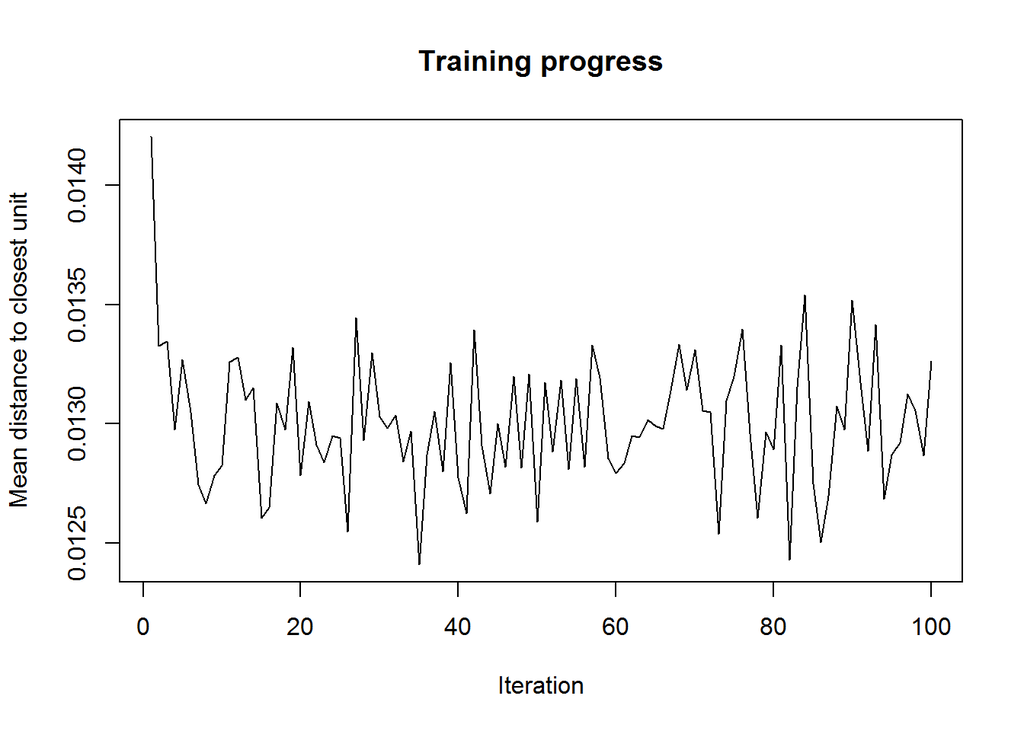

```r
par(mfrow=c(1,1))
plot(speed.rt.Pacc.som,"changes")
```

Create plot of classified data.